# Multilevel models and more on computation

Lab 6, CSSS 564

Connor Gilroy

# Goal

- Understand the concept and uses of multilevel models
- Fit multilevel models in Stan and understand the syntax
- Address computational challenges of MCMC by adjusting the models

# Relevant readings

Why use multilevel models?

http://elevanth.org/blog/2017/08/24/multilevel-regression-as-default/

What’s the algebra?

http://elevanth.org/blog/2017/09/07/metamorphosis-multilevel-model/

What diagnostics are there for making sure your model fit alright?

http://mc-stan.org/bayesplot/articles/visual-mcmc-diagnostics.html

See also:

- Kruschke, Chapter 9 (he calls these “hierarchical models”)
- McElreath, Chapter 12 (pdf here: http://xcelab.net/rmpubs/rethinking/Statistical_Rethinking_sample.pdf)

# Introduction

Multilevel models are about the *partial pooling* of information. They’re useful whenever data are organized into clusters or groups. For instance:

- multiple observations per individual (in medicine, psychology, sports, panel data…)
- classrooms, schools, districts in education data
- geographic regions
- related demographic categories, especially in political or opinion polling—multilevel regression and poststratification (MRP or “Mister P”) is quite common
- studies or polls in meta-analyses

# Setup

```r
library("rstan")
library("tidyverse")
library("bayesplot")

options(mc.cores = parallel::detectCores())
rstan_options(auto_write = TRUE)
theme_set(theme_minimal())
knitr::opts_chunk$set(fig.align = "center")
```

# Model 1: Binary outcome, no covariates

We start with a simple binary outcome model with a link function:

$$y_i \sim \text{Bernoulli}(p_i)$$
$$p_i = \text{logit}^{-1}(\alpha_{unit[i]})$$

What makes it multilevel is that those $\alpha$ values come from a distribution:

$$\alpha_j \sim \text{Normal}(a, \tau)$$

We can put some fairly generic weakly informative priors on the parameters of that distribution:

$$a \sim \text{Normal}(0, 10)$$
$$\tau \sim \text{Cauchy}^+(0, 1)$$

## The data: contraception in Bangladesh

This model uses data from Richard McElreath’s `rethinking` package, and implements the model from the second blog post above. Install the package if you need to.

```r
# devtools::install_github("rmcelreath/rethinking")
data("bangladesh", package = "rethinking")

# subset the data
set.seed(123)
bangladesh <-
  as_tibble(bangladesh) %>%
  sample_n(100)

# look at the data
glimpse(bangladesh)
```

```
## Observations: 100
## Variables: 6
## $ woman             <int> 557, 1524, 791, 1706, 1816, 88, 1019, 1720, ...
## $ district          <int> 15, 46, 25, 52, 57, 1, 30, 52, 31, 27, 58, 2...
## $ use.contraception <int> 1, 1, 1, 1, 0, 0, 1, 1, 0, 1, 0, 1, 0, 0, 0,...
## $ living.children   <int> 4, 1, 4, 4, 4, 4, 4, 2, 1, 3, 1, 1, 4, 3, 3,...
## $ age.centered      <dbl> 14.4400, -12.5600, 4.4400, 3.4400, 6.4400, 0...
## $ urban             <int> 1, 0, 1, 0, 0, 0, 0, 0, 0, 0, 0, 0, 0, 1, 0,...
```

The data are on women’s contraceptive use in Bangladesh. The outcome `use.contraception` is binary, and each woman lives in a `district`. We won’t use the other variables.

We’re subsetting the data because the computational problem isn’t so obvious with the full data.

We created a problem when we sampled, though! Since we sampled, we no longer know if our districts are represented by integers from 1 to J.

```r
unique(bangladesh$district)
```

```
##  [1] 15 46 25 52 57  1 30 31 27 58 40 33  5 53 14 18 41 37 61 39 43 34  7
## [24] 28 45 12 17  6 20 50 44 21 35 38 24 51  8 36 16  9
```

How can we fix that? One way is by playing with data types:

```r
unique(as.integer(as.factor(bangladesh$district)))
```

```
##  [1]  9 33 16 36 38  1 19 20 17 39 28 21  2 37  8 12 29 25 40 27 30 22  4
## [24] 18 32  7 11  3 13 34 31 14 23 26 15 35  5 24 10  6
```

With that in mind, let’s format the data for Stan:

```r
d <- list(
  y = bangladesh$use.contraception,
  district = as.integer(as.factor(bangladesh$district))
)

# Indices
d$N <- length(d$y)
d$J <- length(unique(d$district))
```

## Multilevel model syntax

Let’s have a closer look at what’s going on with all those indices:

```stan
data {
  ...
  // number of districts
  int<lower = 1> J;
  // district index
  int<lower = 1, upper = J> district[N];
  ...
}
...
transformed parameters {
  vector<lower = 0, upper = 1>[N] p;
  for (i in 1:N) {
    p[i] = inv_logit(alpha[district[i]]);
  }
}
...
```

Note: this *isn’t* the most efficient way to fit a logit model in Stan! There’s a shortcut function `bernoulli_logit`:

```stan
model {
  ...
  // likelihood
  for (i in 1:N) {
    y[i] ~ bernoulli_logit(alpha[district[i]]);
  }
}
```

## The centered version of the model

```r
fit_cp <- stan("stan/multilevel_logit_cp.stan", data = d, chains = 2)
print(fit_cp, pars = "tau")
```

```
## Inference for Stan model: multilevel_logit_cp.
## 2 chains, each with iter=2000; warmup=1000; thin=1;
## post-warmup draws per chain=1000, total post-warmup draws=2000.
##
##     mean se_mean   sd 2.5%  25%  50%  75% 97.5% n_eff Rhat
## tau 1.22     0.1 0.58 0.32 0.81 1.15 1.52  2.65    33 1.07
##
## Samples were drawn using NUTS(diag_e) at Thu May 16 11:28:50 2019.
## For each parameter, n_eff is a crude measure of effective sample size,
## and Rhat is the potential scale reduction factor on split chains (at
## convergence, Rhat=1).
```

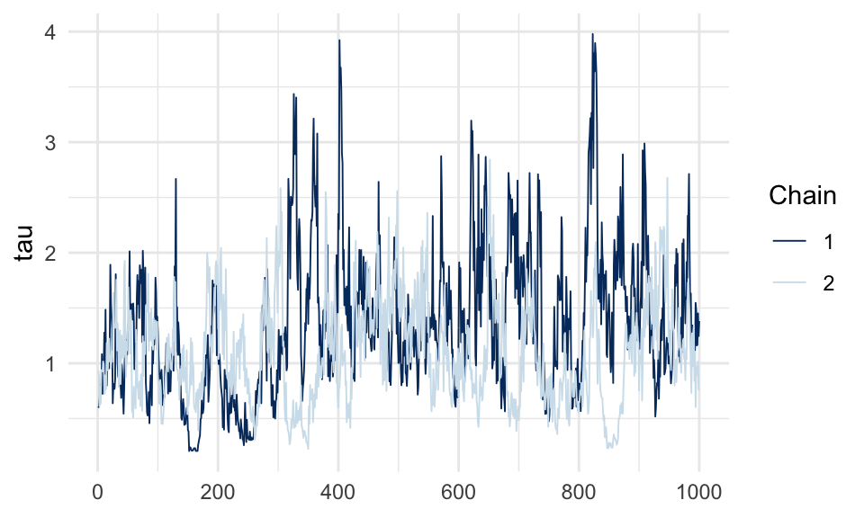

```r
mcmc_trace(as.array(fit_cp), pars = "tau")
```

## The noncentered version

Rewrite the link part like this:

$$\text{logit}(p_i) = a + \tau * z_{unit[i]}$$

Then the distribution for the random effects becomes this:

$$z_j \sim \text{Normal}(0, 1)$$

This can be easier to sample from using HMC. In Stan, we’d change the model to this:

```stan
...
parameters {
  vector[J] z;
  real a;
  real<lower = 0> tau;
}
transformed parameters {
  vector<lower = 0, upper = 1>[N] p;
  for (i in 1:N) {
    p[i] = inv_logit(a + tau * z[district[i]]);
  }
}
model {
  // priors
  z ~ normal(0, 1);
  ...
}
```

```r
fit_ncp <- stan("stan/multilevel_logit_ncp.stan", data = d, chains = 2)
```

```r
print(fit_ncp, pars = "tau")
```

```
## Inference for Stan model: multilevel_logit_ncp.
## 2 chains, each with iter=2000; warmup=1000; thin=1;
## post-warmup draws per chain=1000, total post-warmup draws=2000.
##
##     mean se_mean   sd 2.5%  25% 50%  75% 97.5% n_eff Rhat
## tau 1.14    0.03 0.54 0.18 0.78 1.1 1.45  2.37   388 1.01
##
## Samples were drawn using NUTS(diag_e) at Thu May 16 11:28:52 2019.
## For each parameter, n_eff is a crude measure of effective sample size,
## and Rhat is the potential scale reduction factor on split chains (at
## convergence, Rhat=1).
```

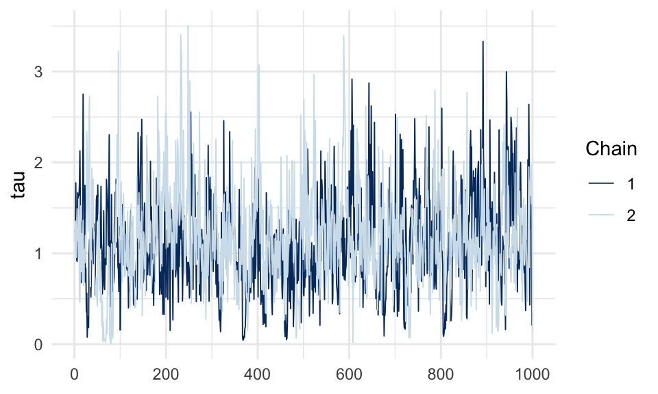

```r
mcmc_trace(as.array(fit_ncp), pars = "tau")
```

# Model 2: Continuous outcome, with covariates

## Data

`nlschools` is a data set of test scores of 8th-grade pupils from different schools in the Netherlands. (`?MASS::nlschools` for more information)

```r
data("nlschools", package = "MASS")

# sample a subset
set.seed(123)
nlschools <-
  as_tibble(nlschools) %>%
  sample_n(200)

# look at the data
glimpse(nlschools)
```

```
## Observations: 200
## Variables: 6
## $ lang  <int> 48, 26, 46, 49, 45, 48, 47, 51, 54, 53, 54, 41, 33, 52, ...
## $ IQ    <dbl> 12.0, 9.0, 11.0, 14.0, 11.0, 13.0, 13.0, 17.5, 12.5, 13....
## $ class <fct> 8080, 19980, 11282, 22480, 24080, 2180, 14880, 22780, 15...
## $ GS    <int> 28, 37, 28, 13, 26, 19, 32, 30, 30, 24, 37, 24, 24, 17, ...
## $ SES   <int> 40, 10, 33, 33, 30, 23, 23, 27, 40, 23, 50, 30, 25, 50, ...
## $ COMB  <fct> 0, 0, 1, 0, 1, 0, 0, 0, 0, 0, 1, 0, 0, 0, 0, 0, 1, 0, 0,...
```

We’ll model language test scores `lang` as a function of class size `GS` and family socio-economic status `SES`.

```r
# format the data into a list for Stan
d_nls <- list()

# vector of scaled outcome
d_nls$y <- as.vector(scale(nlschools$lang))

# matrix of scaled covariates
d_nls$X <-
  nlschools %>%
  select(GS, SES) %>%
  scale() %>%
  as.matrix()

# numeric index from 1..J for the groups
d_nls$group <- as.integer(as.factor(as.integer(nlschools$class)))
```

All the indices!

```r
d_nls$N <- length(d_nls$y)
d_nls$K <- ncol(d_nls$X)
d_nls$J <- length(unique(d_nls$group))
```

## Fit the model

Have a look at `multilevel_regression_cp.stan` and `multilevel_regression_ncp.stan` in the `stan` folder.

First, fit the centered version:

```r
# fit the centered version of the regression
```

```r
# check model summaries and trace plots for model coefficients
```

Then, fit the noncentered version:

```r
# fit the noncentered version of the regression
```

```r
# check model summaries and trace plots for model coefficients
```